# Catch up session text

Maria Teresa Aguilar Rojas

13/09/2021

## What is R?

R is a programming language for statistical computing and graphics supported by the R Foundation for Statistical Computing.

It is free!

Answers to questions in:

https://stackoverflow.com/

https://www.r-bloggers.com/

## Packages

- The capabilities of R are extended through user-created packages
- Packages allow specialised statistical techniques, graphical devices, import/export capabilities, reporting tools (Rmarkdown, knitr, Sweave), etc.

[figure not shown]

## Tidyverse

Group of packages considered a “dialect of the R language”.

Increasingly popular in the R ecosystem.

The packages of tidyverse provide a cohesive collection of functions to deal with common data science tasks, including data import, cleaning, transformation and visualisation.

[figure not shown]

## To practice

Basic syntax

- Comment symbol is #
- Variables are created using <-
- Important: Lower and uppr cases do count!

```r
random <- 30

print(random/10)
```

```
## [1] 3
```

## Install packages

CRAN to computer

```r
 # install.packages("packagename")
 # install.packages("tidyverse")
```

Computer to R program

```r
# library(packagename)
library(tidyverse)
```

## Create a vector/matrix/dataframe

### Create a vector

```r
letters <- c("a", "b", "c", "d")
```

**Create a 3x3 matrix**

```r
matrix(1:9, nrow = 3, ncol = 3)
```

```
##      [,1] [,2] [,3]
## [1,]    1    4    7
## [2,]    2    5    8
## [3,]    3    6    9
```

**Create a dataframe**

**Option 1:** using data.frame

```r
fruits <- c("apple", "orange", "peach")
vegetables <- c("brocoli", "onion", "carrot")

data.frame(fruits,vegetables)
```

```
##   fruits vegetables
## 1  apple    brocoli
## 2 orange      onion
## 3  peach     carrot
```

```r
data.frame(fruits = c("apple", "orange", "peach"), vegetables = c("brocoli", "onion", "carrot"))
```

```
##   fruits vegetables
## 1  apple    brocoli
## 2 orange      onion
## 3  peach     carrot
```

**Option 2:** using the package “tibble” (from tidyverse group)

```r
tibble(x = 1:5, y = 1, z = x ^ 2 + y)
```

```
## # A tibble: 5 x 3
##       x     y     z
##   <int> <dbl> <dbl>
## 1     1     1     2
## 2     2     1     5
## 3     3     1    10
## 4     4     1    17
## 5     5     1    26
```

```r
tibble(fruits = c("apple", "orange", "peach"), vegetables = c("brocoli", "onion", "carrot"))
```

```
## # A tibble: 3 x 2
##   fruits vegetables
##   <chr>  <chr>
## 1 apple  brocoli
## 2 orange onion
## 3 peach  carrot
```

## Set the working directory

```r
setwd("C:/Users/teres/OneDrive/Documents/Teaching/Econometrics course/rémise à niveau")
```

## Upload a dataset

If data is in xlsx format

```r
library(xlsx)
data <- read.xlsx("databasename.xls", sheetName = "Content")
```

If data is in Text format

```r
library(readr)
dataset <- read_csv(NULL)
```

If data is in Stata format

```r
library(haven)
dataset <- read_stata(NULL)
```

In our case the data is in csv format

```r
movies <- read.csv("IMDB.csv", header=T, as.is=T)

class(movies)
```

```
## [1] "data.frame"
```

```r
summary(movies)
```

```
##        X             Title               Rating       TotalVotes
##  Min.   :  1.00   Length:118         Min.   :7.500   Length:118
##  1st Qu.: 30.25   Class :character   1st Qu.:7.700   Class :character
##  Median : 59.50   Mode  :character   Median :7.800   Mode  :character
##  Mean   : 59.50                      Mean   :7.873
##  3rd Qu.: 88.75                      3rd Qu.:8.000
##  Max.   :118.00                      Max.   :8.800
##
##     Genre1             Genre2             Genre3            MetaCritic
##  Length:118         Length:118         Length:118         Min.   : 62.00
##  Class :character   Class :character   Class :character   1st Qu.: 72.00
##  Mode  :character   Mode  :character   Mode  :character   Median : 78.00
##                                                           Mean   : 77.82
##                                                           3rd Qu.: 82.50
##                                                           Max.   :100.00
##                                                           NA's   :7
##     Budget            Runtime           ï..CVotes10        CVotes09
##  Length:118         Length:118         Min.   :  2060   Min.   :  4083
##  Class :character   Class :character   1st Qu.: 21162   1st Qu.: 33400
##  Mode  :character   Mode  :character   Median : 45584   Median : 63412
##                                        Mean   : 64751   Mean   : 81994
##                                        3rd Qu.: 75413   3rd Qu.:103349
##                                        Max.   :584839   Max.   :485218
##
##     CVotes08         CVotes07         CVotes06        CVotes05
##  Min.   :  9078   Min.   :  5309   Min.   : 1668   Min.   :  550
##  1st Qu.: 63652   1st Qu.: 40413   1st Qu.:13878   1st Qu.: 4550
##  Median :105649   Median : 67490   Median :24260   Median : 8404
##  Mean   :112316   Mean   : 68658   Mean   :24889   Mean   : 9067
##  3rd Qu.:160771   3rd Qu.: 95702   3rd Qu.:33376   3rd Qu.:12308
##  Max.   :304457   Max.   :162604   Max.   :67579   Max.   :27957
##
##     CVotes04        CVotes03         CVotes02       CVotes01
##  Min.   :  226   Min.   : 131.0   Min.   :  79   Min.   :  200
##  1st Qu.: 1664   1st Qu.: 858.8   1st Qu.: 541   1st Qu.: 1296
##  Median : 3300   Median :1850.0   Median :1086   Median : 2573
##  Mean   : 3850   Mean   :2196.2   Mean   :1515   Mean   : 3617
##  3rd Qu.: 5277   3rd Qu.:3080.0   3rd Qu.:2202   3rd Qu.: 4816
##  Max.   :12286   Max.   :7868.0   Max.   :5751   Max.   :15768
##
```

[output cut: 57 more lines]

```
##  Min.   :7.100   Min.   :5.800   Min.   :5.900   Min.   :6.400
##  1st Qu.:7.500   1st Qu.:7.600   1st Qu.:7.600   1st Qu.:7.000
##  Median :7.600   Median :7.800   Median :7.900   Median :7.200
##  Mean   :7.627   Mean   :7.781   Mean   :7.827   Mean   :7.236
##  3rd Qu.:7.800   3rd Qu.:8.000   3rd Qu.:8.100   3rd Qu.:7.500
##  Max.   :8.100   Max.   :8.500   Max.   :9.100   Max.   :8.200
##
##     VotesUS         VotesnUS
##  Min.   :7.400   Min.   :7.300
##  1st Qu.:7.800   1st Qu.:7.600
##  Median :7.900   Median :7.700
##  Mean   :7.938   Mean   :7.783
##  3rd Qu.:8.100   3rd Qu.:7.900
##  Max.   :8.700   Max.   :8.800
##                  NA's   :1
```

Source of the data: https://data.world/priyankad0993/top-50-imdb-movies-based-on-ratings#

## Pipping

Pipping refers to chaining actions in a series of steps. The key element to pipping is %>%

```r
my_data %>%
  do_this_thing() %>%
  now_do_that_thing() %>%
  and_one_more()
```

## Separating and uniting columns

Separating and uniting two columns

```r
#To separate
data %>% separate(Variable, into = c("X", "Y"), sep = "")

#To unite
data %>% unite(Variable, c("X", "Y"), sep = "_", remove = TRUE, na.rm = FALSE)
```

In our example

```r
movies <- movies %>% separate(Title, into = c("Title", "Year"), sep = "[()]") #A bracket expression is a list of characters enclosed by ‘[’ and ‘]’. It matches any single character in that list. If the first character of the list is the caret ‘^’, then it matches any character not in the list
```

```r
# Uniting two columns
# movies <- movies %>% unite(Title, c("Title", "Year"), sep = "_", remove = TRUE, na.rm = FALSE)
#
# movies <- movies %>% separate(Title, into = c("Title", "Year"), sep = "_") #A bracket expression is a list of characters enclosed by '[' and ']'. It matches any single character in that list. If the first character of the list is the caret '^', then it matches any character not in the list
```

## Mutate

Create new variables within the original dataset

```r
my_data <- my_data %>%
mutate(variable = expression)
```

In our example:

Let’s get the log of variable rating

```r
movies %>%
  mutate(log_rating = log(Rating))
```

[output not shown]

To replace strings in the data

```r
# Replacing a single string

movies[11,2] <- "Birdman"
movies[11,3] <- "2014"


# Replacing multiple strings under the same condition

# movies2 <- movies %>% mutate(Title = replace(Title, Title == "Birdman or ", "Birdman")) %>%
#                        mutate(Year = replace(Year, Year == "The Unexpected Virtue of Ignorance", "2014"))
```

To convert variable types

```r
movies <- movies %>%
  mutate(TotalVotes = parse_number(TotalVotes)) %>%
  mutate(Budget  = parse_number(Budget))
```

```r
# To create dummy variables
movies <- movies %>% mutate(drama = ifelse(Genre1 == "Drama", 1, 0)) %>%
                     mutate(dramaorbio = ifelse(Genre1 == "Drama"|Genre1 == "Biography", 1, 0)) %>%
                     mutate(log_rating = log(Rating))
```

## Omit missing values

```r
movies <- movies %>%
  na.omit()
```

## Arrange

```r
# for ascending order:

movies_arranged <- movies %>% arrange(Rating)

# for descending order:
movies_arranged <- movies %>% arrange(-Rating)
# movies <- movies %>% arrange(desc(Rating))

# to sort by one variable then another
movies_arranged <- movies %>% arrange(Year,desc(Rating))
```

## Filter

```r
Action <- movies %>%
  filter(Genre1 == "Action")
```

## Select

```r
# keeps all rows, but only retain the columns for VARIABLE1 and VARIABLE2
# data %>% select(VARIABLE 1, VARIABLE2)

submovies <- movies %>%
  select(Title, Year, Rating, TotalVotes)
```

**Reminder:** arrange, filter, select DON’T change the original data set. Instead they return a new one, which you can assign to a variable

```r
Adventure <- movies %>%
  filter(Genre1 == "Adventure") %>%
  select(Title, Year, Rating, TotalVotes) %>%
  arrange(Year,desc(Rating), desc(TotalVotes))
```

## Group et summarise

```r
# Group by gender and obtain the mean and median of their rating
summovies <- movies %>%
  group_by(Genre1) %>%
  summarise(
    mean_rating = mean(Rating),
    median_rating = median(Rating, na.rm = TRUE), #Handling with missing values
    std_dev = sd(Rating),
    count = n(),
    mean_ratingF = mean(VotesF),
    mean_ratingM = mean(VotesM)
  )

print(summovies)
```

```
## # A tibble: 8 x 7
##   Genre1    mean_rating median_rating std_dev count mean_ratingF mean_ratingM
##   <chr>           <dbl>         <dbl>   <dbl> <int>        <dbl>        <dbl>
## 1 Action           7.89          7.8    0.291    27         7.90         7.86
## 2 Adventure        7.87          7.85   0.296    12         7.96         7.84
## 3 Animation        7.9           7.8    0.204    13         8.1          7.82
## 4 Biography        7.91          7.9    0.209    15         7.97         7.87
## 5 Comedy           7.82          7.8    0.178    11         7.83         7.79
## 6 Crime            7.87          7.8    0.194     9         7.76         7.87
## 7 Drama            7.90          7.9    0.238    21         7.90         7.88
## 8 Mystery          8.1           8.1   NA         1         8.2          8.1
```

## Convert data from wide to long

```r
summovies_long <- summovies %>%
  gather("mean_ratingF", "mean_ratingM", key = Gender , value = ratingFH)

summovies_long <- summovies_long %>% mutate(Gender = replace(Gender, Gender == "mean_ratingF", "Female")) %>%
                                     mutate(Gender = replace(Gender, Gender == "mean_ratingM", "Male"))

# If long to wide

# wide = longdata1 %>%
#   spread(Year, BMI)
# wide
```

## Frequency table

```r
movies %>%
  group_by(Genre1) %>%
  summarise(count = n())
```

```
## # A tibble: 8 x 2
##   Genre1    count
##   <chr>     <int>
## 1 Action       27
## 2 Adventure    12
## 3 Animation    13
## 4 Biography    15
## 5 Comedy       11
## 6 Crime         9
## 7 Drama        21
## 8 Mystery       1
```

##Plot using ggplot2

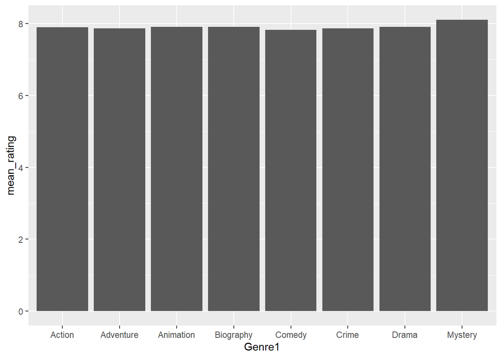

```r
# Barplot

summovies %>% ggplot(aes(x = Genre1, y = mean_rating)) +
                       geom_col()
```

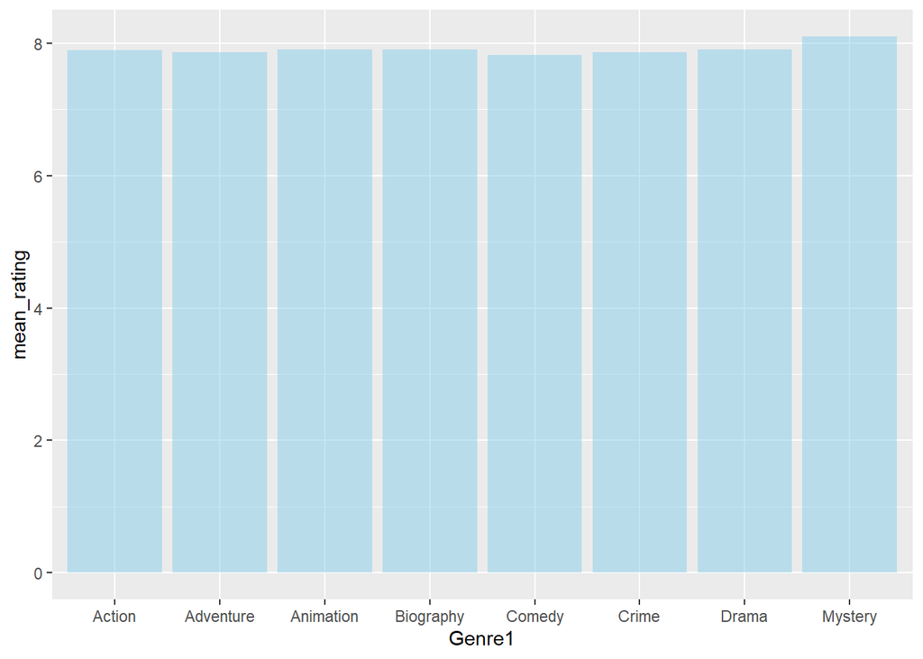

```r
summovies %>%
  ggplot(aes(x = Genre1, y = mean_rating)) +
  geom_col(fill="skyblue", alpha=0.5)
```

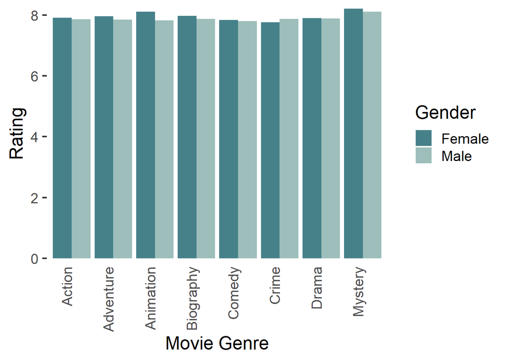

```r
# Grouped bar plot

summovies_long %>%
 ggplot() +
  # add bar for each discipline colored by gender
  geom_bar(aes(x = Genre1, y = ratingFH, fill = Gender),
           stat = "identity", position = "dodge") +
  # name axes and remove gap between bars and y-axis
  scale_y_continuous("Rating", expand = c(0, 0)) +
  scale_x_discrete("Movie Genre") +
  scale_fill_manual(values = c("#468189", "#9DBEBB")) +
  # remove grey theme
  theme_classic(base_size = 18) +
  # rotate x-axis and remove superfluous axis elements
  theme(axis.text.x = element_text(angle = 90,
                                   hjust = 1, vjust = 0),
        axis.line = element_blank(),
        axis.ticks.x = element_blank())
```

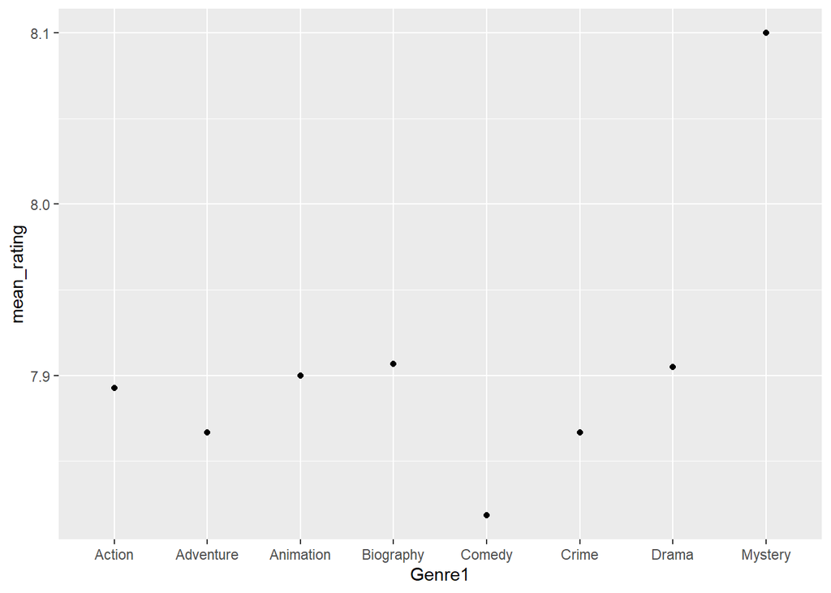

```r
# Point plot

summovies %>% ggplot(aes(x=Genre1, y=mean_rating)) +
  geom_point()
```

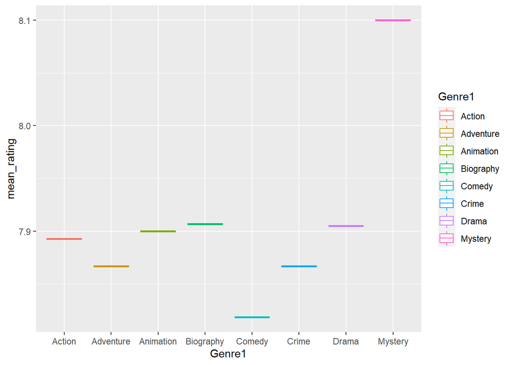

```r
#Boxplot

# If you want to store the variable
boxplot <- summovies %>%
  ggplot(aes(x = Genre1,y = mean_rating, colour = Genre1)) +
  geom_boxplot()


# If you want to draw the plot after storing
plot(boxplot)
```

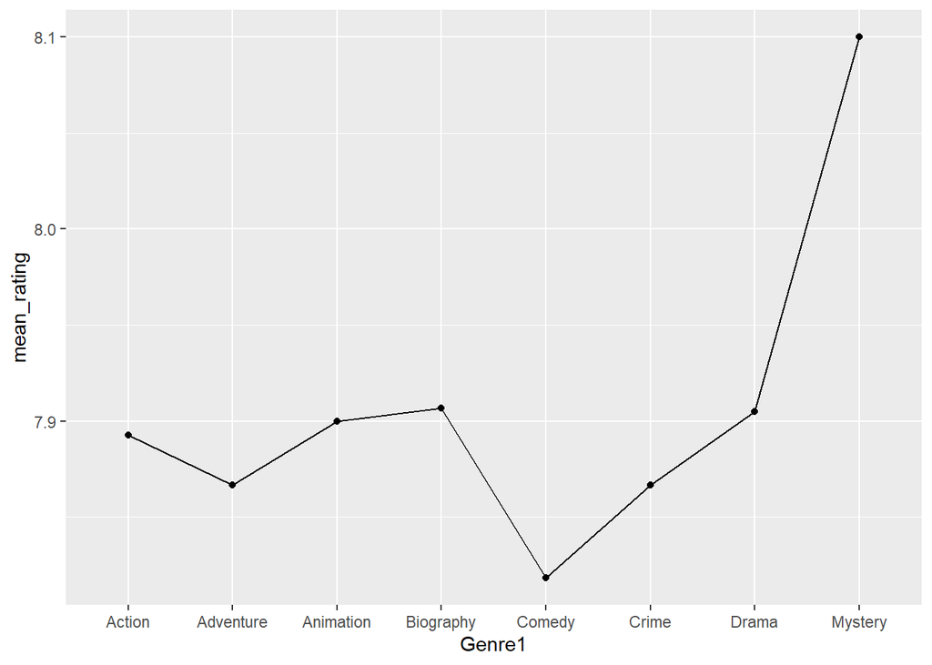

```r
# Lineplot
summovies %>% ggplot(aes(x=Genre1, y=mean_rating, group=1)) +
  geom_line()+
  geom_point()
```

```r
# Density plot

#Option 1
density(movies$Rating)
```

```
##
## Call:
##  density.default(x = movies$Rating)
##
## Data: movies$Rating (109 obs.);  Bandwidth 'bw' = 0.07884
##
##        x               y
##  Min.   :7.263   Min.   :0.0005222
##  1st Qu.:7.707   1st Qu.:0.0475967
##  Median :8.150   Median :0.1806988
##  Mean   :8.150   Mean   :0.5634223
##  3rd Qu.:8.593   3rd Qu.:1.2167270
##  Max.   :9.037   Max.   :1.6793332
```

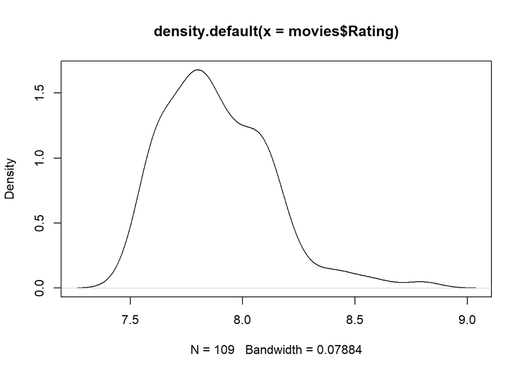

```r
plot(density(movies$Rating))
```

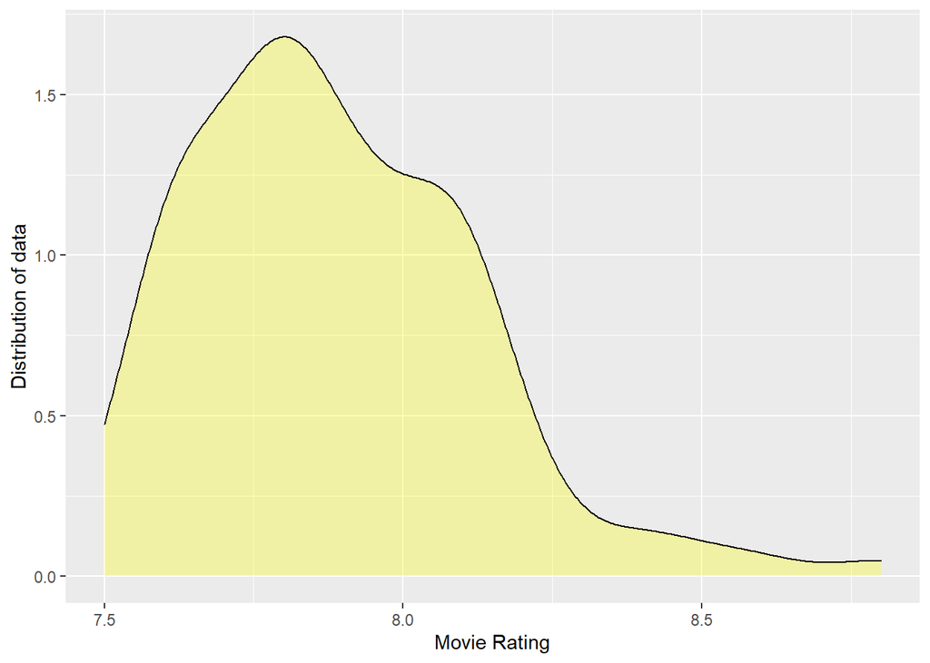

```r
#Option 2
movies %>% ggplot(aes(Rating)) + geom_density(fill = "yellow", alpha = .3) + labs(x = "Movie Rating", y = "Distribution of data")
```

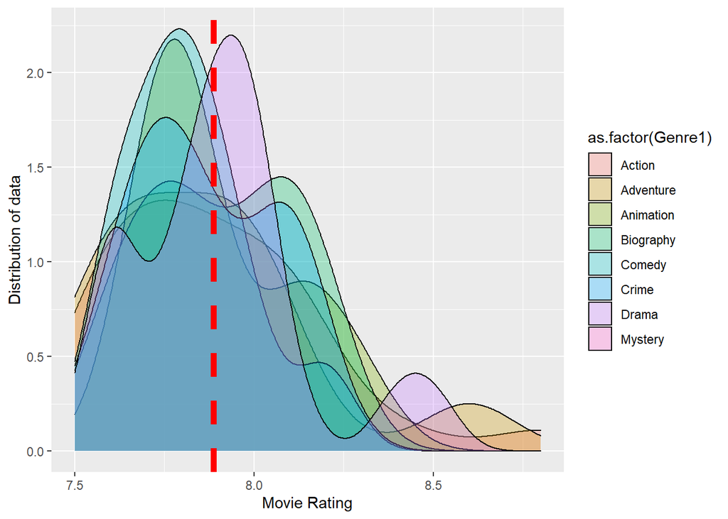

```r
# + geom_vline(xintercept = 8, size = 2, color = "red", linetype = "dashed")
# + facet_grid(. ~Genre1)

movies %>% ggplot(aes(Rating, fill = as.factor(Genre1))) + geom_density(alpha = .3) + labs(x = "Movie Rating", y = "Distribution of data") + geom_vline(xintercept = mean(movies$Rating), size = 2, color = "red", linetype = "dashed")
```

## Correlations

```r
movies %>%
  select(Rating, TotalVotes, Budget)%>%
  cor()
```

```
##              Rating TotalVotes    Budget
## Rating     1.000000  0.6161970 0.2466900
## TotalVotes 0.616197  1.0000000 0.5768795
## Budget     0.246690  0.5768795 1.0000000
```

## Inferential Statistics

```r
# Regression

# y = x1 + X2
# rating explained by budget, age, drama, ...

regression <- lm(Rating ~ Budget + dramaorbio, data=movies)
summary(regression)
```

```
##
## Call:
## lm(formula = Rating ~ Budget + dramaorbio, data = movies)
##
## Residuals:
##      Min       1Q   Median       3Q      Max
## -0.44811 -0.15891 -0.00619  0.12399  0.84109
##
## Coefficients:
##              Estimate Std. Error t value Pr(>|t|)
## (Intercept) 7.786e+00  3.979e-02 195.686   <2e-16 ***
## Budget      1.080e-09  3.442e-10   3.138   0.0022 **
## dramaorbio  8.984e-02  5.087e-02   1.766   0.0803 .
## ---
## Signif. codes:  0 '***' 0.001 '**' 0.01 '*' 0.05 '.' 0.1 ' ' 1
##
## Residual standard error: 0.2299 on 106 degrees of freedom
## Multiple R-squared:  0.0877, Adjusted R-squared:  0.07049
## F-statistic: 5.095 on 2 and 106 DF,  p-value: 0.007715
```

```r
# Rating <- by the public in general
# MetaCritic <- by experts
regression2 <- lm(MetaCritic ~ Budget + dramaorbio, data=movies)
summary(regression2)
```

```
##
## Call:
## lm(formula = MetaCritic ~ Budget + dramaorbio, data = movies)
##
## Residuals:
##      Min       1Q   Median       3Q      Max
## -18.6171  -5.7256   0.0124   5.9939  19.0884
##
## Coefficients:
##               Estimate Std. Error t value Pr(>|t|)
## (Intercept)  7.781e+01  1.496e+00  52.022   <2e-16 ***
## Budget      -1.402e-08  1.294e-08  -1.084    0.281
## dramaorbio   3.157e+00  1.912e+00   1.651    0.102
## ---
## Signif. codes:  0 '***' 0.001 '**' 0.01 '*' 0.05 '.' 0.1 ' ' 1
##
## Residual standard error: 8.643 on 106 degrees of freedom
## Multiple R-squared:  0.05571,    Adjusted R-squared:  0.03789
## F-statistic: 3.127 on 2 and 106 DF,  p-value: 0.04793
```